Home > Archives > 分组可视化简介

# 分组可视化简介

Publish: February 15, 2015

# 分组可视化

zengfan

2015年2月16日

## 引言

可视化并不是用数据做出漂亮的图形，而是一个可以洞察隐藏数据模式的工具。通过这个工具以完成人和数的沟通。其中分组可视化是将一个数据集可视化为一系列使用相同坐标和尺度的图的方法，目的是为了让不同的图形轻松进行比较，最早由Edward Tufte提出来的，他使用“small multiples”这一次来表达这种技术。

Edward Tufte (Envisioning Information, p. 67):

> At the heart of quantitative reasoning is a single question: Compared to what? Small multiple designs, multivariate and data bountiful, answer directly by visually enforcing comparisons of changes, of the differences among objects, of the scope of alternatives. For a wide range of problems in data presentation, small multiples are the best design solution.

可见分组可视化是一种功能很强大的方法，很容易的对不同的变量分组比较，比如根据时间和颜色进行分组比较。

然而在大多数工具中，比如Excel、SAS甚至Tableau等，分组可视化都是比较难以实现的，而在R中，却变得很容易。

在R中的ggplot2包中，分组可视化的技术，被称为faceting。

## 举例

为了介绍ggplot2中faceting这种技术，我们使用一个包含3个不同地区12个月的销售数据，然后找到这个数据的模式。

我们首先使用线图进行不分组的可视化：

```r
library(ggplot2)

#读取数据
df.facet_data <- read.csv(url("http://www.sharpsightlabs.com/wp-content/uploads/2014/12/facet_dummy_data.csv"))
head(df.facet_data)
```

```
##          region month sales
## 1 North America   Jan  1800
## 2 North America   Feb  1500
## 3 North America   Mar  1700
## 4 North America   Apr  1900
## 5 North America   May  1950
## 6 North America   Jun  2000
```

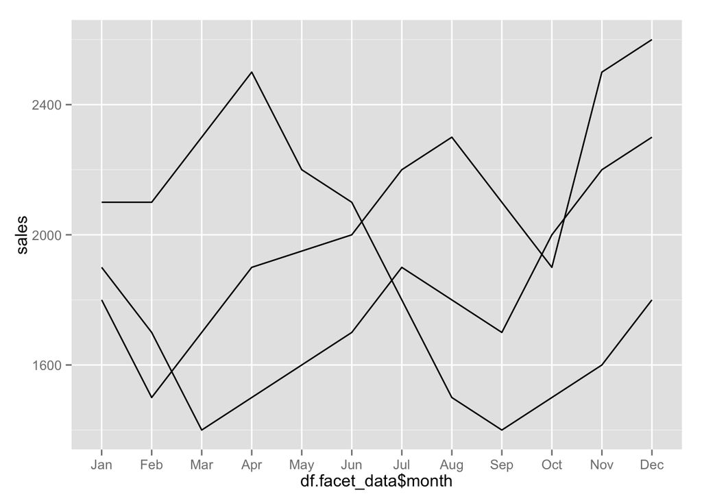

```r
#数据操作
df.facet_data$month <- factor(df.facet_data$month, levels=month.abb)
#使用ggplot2画图
ggplot(data=df.facet_data, aes(x=df.facet_data$month,y=sales, group=region)) +
  geom_line()
```

facet_grid() 将不同组别的图放在一个行列格子里，方便进行比较。

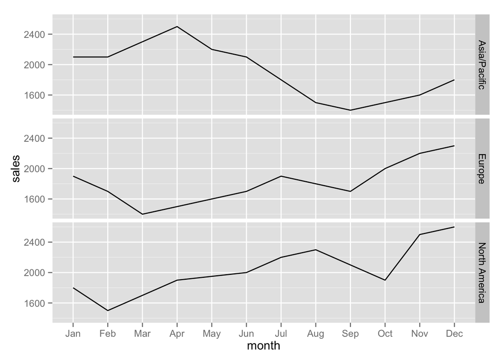

```r
ggplot(data=df.facet_data, aes(x=month,y=sales, group=1)) +
  geom_line() +
  facet_grid(region ~ .)
```

注意上面的代码和前面的代码一样，但是在后面增加了facet_grid(region ~ .)。这个函数指定布局的行列，“~”左右分别指定行分类与列分类，这里“.”表示我们希望只用一维的格子（不指定列分类）。

facet_grid(region~.)做了下面这几件事情： 1. 创建了一个图表，这个图的行按region进行了划分，每个行的标度都是相同的 2. 根据region分别创建了一个图形 3. 将这些图形按照顺序放在每一行上

### facet_wrap()

facet_wrap()是另外一种方式，他将所有分类的数据图当做一个图像带，将每个图一个接一个的放在这个图像带上。

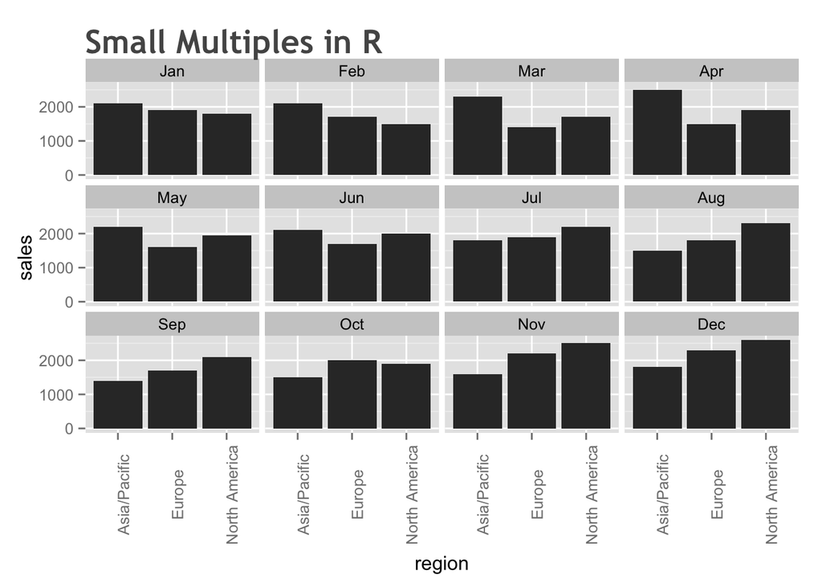

```r
#我们用facet_wrap()对进行可视化

ggplot(data=df.facet_data, aes(x=region,y=sales)) +
  geom_bar(stat="identity") +
  facet_wrap(~month) +
  ggtitle("Small Multiples in R") +
  theme(plot.title = element_text(family="Trebuchet MS", face="bold", size=20, hjust=0, color="#555555")) +
  theme(axis.text.x = element_text(angle=90))
```

facet_wrap(~month)这个方法为每月都画了一个bar图，并将这些图放在一个图像带中。

我们也可指定这个ribbon的列的数量。

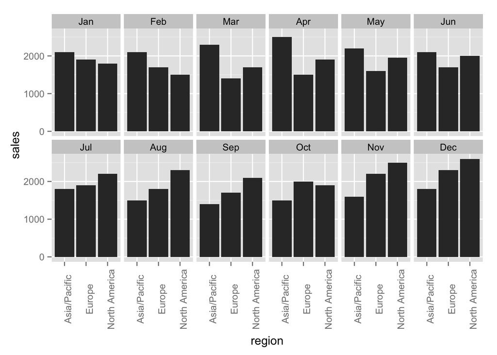

```r
ggplot(data=df.facet_data, aes(x=region,y=sales)) +
  geom_bar(stat="identity") +
  facet_wrap(~month, ncol=6) +
  theme(axis.text.x = element_text(angle=90))
```

这只是ggplot2图像布局方法中较为简单的一种，还有很多复杂的布局方法等待你的探索。

以上这些例子都是基本的分组可视化的例子，我们可以看到它可以帮我们分析不同时间的数据、不同组别的数据。不论以后你的工作时进行数据探索还是模型，可视化都是非常重要的一个部分。 To explore your data visually.

随着你探索的数据集越来越大（这是一个趋势），分组可视化技术就变得越来越重要了。

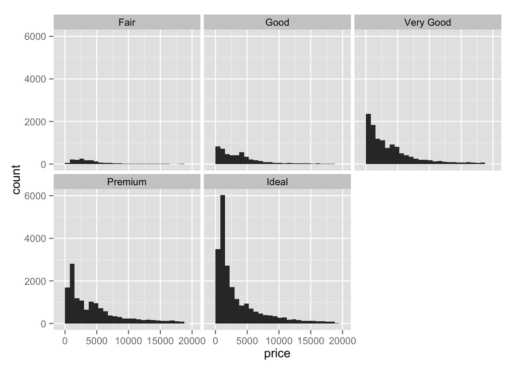

```r
library(ggplot2)
ggplot(data=diamonds, aes(x=price)) +
  geom_histogram(binwidth=750) +
  facet_wrap(~cut)
```

### 多变量分组可视化分析

分组可视化技术还可以同时对不同的变量进行分组比较。我们可以在facets的函数中，增加其他的维度进行比较。 比如：

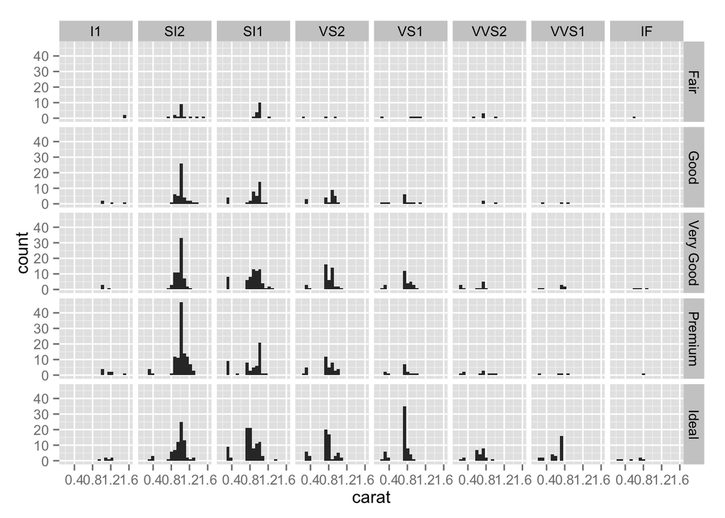

```r
carat<-diamonds[sample(10000,1000),]
ggplot(carat,aes(carat))+geom_histogram(binwidth=0.07)+facet_grid(cut~clarity)
```

声明: 本文采用 [BY-NC-SA](http://creativecommons.org/licenses/by-nc-sa/3.0/) 授权。转载请注明转自: tegulia

« Scrum系列之sprint周期详解

Ggplot2交互式可视化步骤示例 »